# Working with National Land Cover Database (NLCD) in R: Raster package and treemaps with ggplot2

Small Town Big Data

January 24, 2021

This tutorial accompanies the Small Town Big Data blog post [Towns, they are a’changin’. Read it here](https://www.smalltownbigdata.com/post/steamboat-springs-land-cover-data-nlcd).

### Welcome to R. It’s the GIS you never knew you needed. Let’s get set up and do some math with maps.

This tutorial offers an introduction to working with National Land Cover Database rasters in R. We’ll cover:

- Loading and plotting a series of rasters
- Animating a series of rasters in a GIF file
- Basic dataframe manipulation using a for loop to summarize raster data
- Treemaps in Ggplot2

Software: If you’re a beginner, I recommend downloading [RStudio](https://rstudio.com/products/rstudio/download/). Open up a new .R file and start cutting and pasting!

Data: You can peruse and download NLCD data [here](https://www.mrlc.gov/viewer/)

The projection is a little funky, and cropping and clipping to a county boundary can take a lot of processing time. To give you a little head start, I’ve projected, clipped and trimmed seven timesteps of Routt County NLCD for you, and included it in this repository. But feel free to download your own area of interest and let me know what you find!

**Let’s jump right in.**

### Loading raster data

```r
# Set your working directory to the /data folder included in the repository using setwd().
# Install the following packages for this tutorial:
# install.packages(c("FedData", "rasterVis", "raster","sp", "rgdal", "reshape2", "treemapify", "ggplot2", "kableExtra", "animation" "scales"))
library(FedData)
library(rasterVis)
library(raster)
library(sp)
library(rgdal)
library(reshape2)
library(treemapify)
library(ggplot2)
library(kableExtra)
library(animation)
library(scales)

# Load a single raster using the raster() function This is the
r<-raster("nlcd_1.tif")

# What does a raster object look like in R? What are the key attributes of this data format?
r
```

```
## class      : RasterLayer
## dimensions : 4311, 2513, 10833543  (nrow, ncol, ncell)
## resolution : 30.1, 29.6  (x, y)
## extent     : 289422, 365063.3, 4417034, 4544639  (xmin, xmax, ymin, ymax)
## crs        : +proj=utm +zone=13 +datum=WGS84 +units=m +no_defs
## source     : C:/Users/ncinglis/Desktop/stbd/nlcd/nlcd_1.tif
## names      : nlcd_1
## values     : 11, 95  (min, max)
```

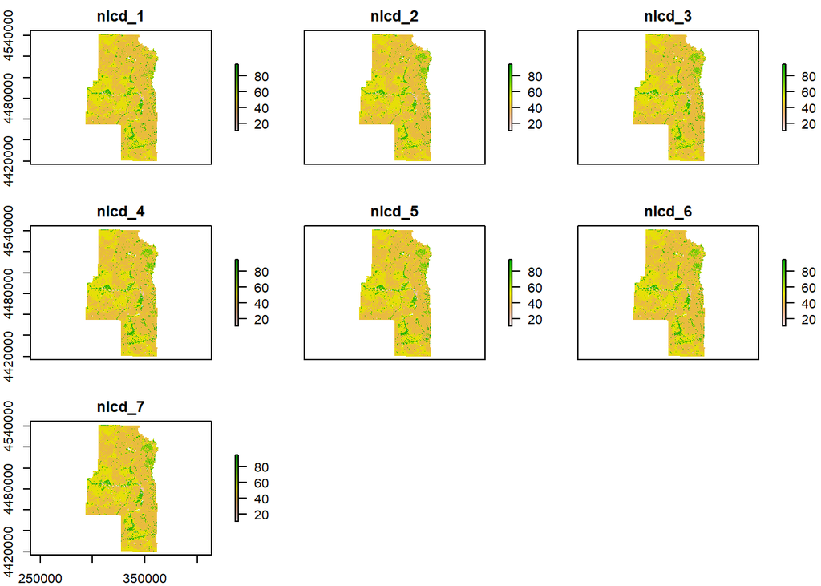

```r
# We have seven different years of NLCD data. The stack() function takes as many rasters as you give it and stacks them into one object.
# If they have the same resolution, extent and spatial reference, this is an easy way to conduct operations on multiple layers at the same time.

# We can load in the NLCD series straight into a stack.I do this so often that I wrote a little function that takes a regular expression and creates a raster stack from the files that match it.

list2stack <- function(x) {
  z<-list.files(pattern = x)
  y<-raster::stack(z)
  return(y)
}

# If you want to get into regular expressions, there are entire books on it. Just trust me this one works:
p<-"^nlcd_.*\\.tif$"
s<-list2stack(p)

#Let's plot this stack and take a look at it.
plot(s)
```